# Test a Perceptual Phenomenon

### Analyzing the Stroop Effect

Perform the analysis in the space below. Remember to follow [the instructions](https://docs.google.com/document/d/1-OkpZLjG_kX9J6LIQ5IltsqMzVWjh36QpnP2RYpVdPU/pub?embedded=True) and review the [project rubric](https://review.udacity.com/#!/rubrics/71/view) before submitting. Once you've completed the analysis and write up, download this file as a PDF or HTML file and submit in the next section.

(1) What is the independent variable? What is the dependent variable?

Independent Variable is whether the Font name and color are similar or different. Dependent variable is the reaction time between the stimulus and response.

(2) What is an appropriate set of hypotheses for this task? What kind of statistical test do you expect to perform? Justify your choices.

Null Hypothesis(H0) : There is no significant difference in time for the population to state the colors of the words in a congruent or incongruent condition. Alternate Hypothesis(H1) : There is significant difference in time for the population to state the colors of the words in a congruent or incongruent condition.

H0: μcongruent - μincongruent = 0 H1: μcongruent - μincongruent != 0

The statistical method preferred is a 2-sample paired T-test because both congruent and incongruent times are calculated from same population.And that the standard deviation of the population is not known.

(3) Report some descriptive statistics regarding this dataset. Include at least one measure of central tendency and at least one measure of variability. The name of the data file is 'stroopdata.csv'.

```python
import pandas as pd
import matplotlib.pyplot as plt
import numpy as np
data = pd.read_csv('stroopdata.csv')
data.head(6)
print(data['Congruent'].mean())
print(data['Incongruent'].mean())
print(np.var(data['Congruent']))
print(np.var(data['Incongruent']))
```

```
14.051125
22.0159166667
12.1411528594
22.0529338264
```

(4) Provide one or two visualizations that show the distribution of the sample data. Write one or two sentences noting what you observe about the plot or plots.

```
{'boxes': [<matplotlib.lines.Line2D at 0x7fb863ad8c88>],
 'caps': [<matplotlib.lines.Line2D at 0x7fb863aea7b8>,
 'fliers': [<matplotlib.lines.Line2D at 0x7fb863a764a8>],
 'means': [],
 'medians': [<matplotlib.lines.Line2D at 0x7fb863a76048>],
 'whiskers': [<matplotlib.lines.Line2D at 0x7fb863ad8e10>,
```

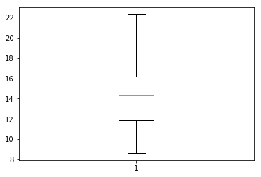

```python
plt.boxplot(data['Congruent'])
```

```
{'boxes': [<matplotlib.lines.Line2D at 0x7fb8639f4cc0>],
 'caps': [<matplotlib.lines.Line2D at 0x7fb8639ff828>,
 'fliers': [<matplotlib.lines.Line2D at 0x7fb863a06588>],
 'means': [],
 'medians': [<matplotlib.lines.Line2D at 0x7fb863a06128>],
 'whiskers': [<matplotlib.lines.Line2D at 0x7fb8639f4e48>,
```

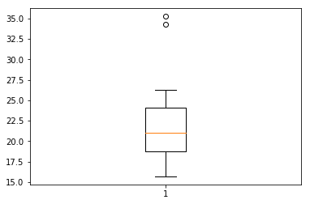

```python
plt.boxplot(data['Incongruent'])
```

We can see from both the boxplots that the mean time required for responding to congruent type words is less than mean time required for responding to Incongruent words.So from the sample provided , we can say that less amount of response time is needed for reacting to congruent words than Incongruent ones. And we also see that there are few outliers in Incogruent boxplot.

(5) Now, perform the statistical test and report the results. What is the confidence level and your critical statistic value? Do you reject the null hypothesis or fail to reject it? Come to a conclusion in terms of the experiment task. Did the results match up with your expectations?

```python
from scipy import stats

stats.ttest_rel(data['Congruent'],data['Incongruent'])
```

```
Ttest_relResult(statistic=-8.020706944109957, pvalue=4.1030005857111781e-08)
```

Assume the significance level as 0.05.The p-value is very less.So we should reject the Null Hypothesis.We conclude that there is significant difference in time for recognising Congruent and Incongruent words.And yes the results of hypothesis testing and the inference from the box plots above reflect the same conclusion.